# workspace_coverplot_ad_R_solutions

Tobias Stalder

17 12 2020

## 1 Document Purpose

This document shows the workflow of creating cover plots for the new book of Henning Bumann and Malte Grosser “Advanced R Solutions - a bookdown projects”. I show all code needed for the different plot designs as well as the underlying desicion making. Plot ideas that did not make it to the second iteration are not part of this documentation.

**Load libraries and set working dir (and install with dependencies if needed)**

```r
setwd(r"(C:\Users\tobia\OneDrive\Desktop\ownprojects\cover_advanced_R)")

packages <- c("tidyverse", "Cairo", "ggpubr", "ggalt", "ggbump", "scales", "prismatic", "treemapify","GGally",
              "intergraph", "ggraph", "visNetwork", "threejs", "networkD3", "ndtv", "igraph")

package.check <- lapply(
  packages,
  FUN = function(x) {
    if (!require(x, character.only = TRUE)) {
      install.packages(x, dependencies = TRUE)
      library(x, character.only = TRUE)
    }
  }
)
```

**Load data from local dir and direct cleaning to long format**.

The following snippet was copied from the book repo (originally written by Henning Bumann)

```r
df_long <- read.csv2(r"(progress_data.csv)", stringsAsFactors = FALSE,
                     header = TRUE) %>%
  as_tibble() %>%
  mutate(status = "finalised") %>%
  modify_at("status", factor,
            levels = c("open", "started", "solved", "reviewed", "finalised")) %>%
  tibble::rowid_to_column("id") %>%
  separate(chapter, "nr", sep = " ", remove = FALSE, extra = "drop") %>%
  mutate(nr = as.integer(nr),
         chapter = factor(chapter),
         chapter = fct_reorder(chapter, nr, .desc = FALSE),
         part = case_when(nr < 9 ~ "Foundations",
                          nr < 12 ~ "Functional\nProgramming",
                          nr < 17 ~ "Object Oriented\nProgramming",
                          nr < 22 ~ "Metaprogramming",
                          TRUE    ~ "Techniques"),
         part = factor(part, levels = c("Foundations", "Functional\nProgramming",
                                        "Object Oriented\nProgramming",
                                        "Metaprogramming", "Techniques"))) %>%
  add_count(chapter)
df_long$subchapter = factor(df_long$subchapter)
head(df_long)
```

```
## # A tibble: 6 x 11
##      id rawid chapter    nr subchapter exercise status updated_when updated_by
##   <int> <int> <fct>   <int> <fct>         <int> <fct>  <chr>        <chr>
## 1     1     1 2 Name~     2 Binding b~        1 final~ 06.02.2019   -
## 2     2     2 2 Name~     2 Binding b~        2 final~ 06.02.2019   -
## 3     3     3 2 Name~     2 Binding b~        3 final~ 06.02.2019   -
## 4     4     4 2 Name~     2 Binding b~        4 final~ 06.02.2019   -
## 5     5     5 2 Name~     2 Binding b~        5 final~ 06.02.2019   -
## 6     6     6 2 Name~     2 Copy-on-m~        1 final~ 06.02.2019   -
## # ... with 2 more variables: part <fct>, n <int>
```

**data summaries for later plotting**

For some vizualisations I need more summarised data. Thus, I create 2 new dfs with different summary variables of n exercises.

```r
df_long %>%
  group_by(chapter) %>%
  count(subchapter, part) -> amounts
head(amounts)
```

```
## # A tibble: 6 x 4
## # Groups:   chapter [2]
##   chapter            subchapter      part            n
##   <fct>              <fct>           <fct>       <int>
## 1 2 Names and values Binding basics  Foundations    75
## 2 2 Names and values Copy-on-modify  Foundations    60
## 3 2 Names and values Modify-in-place Foundations    45
## 4 2 Names and values Object size     Foundations    45
## 5 3 Vectors          Atomic vectors  Foundations    95
## 6 3 Vectors          Attributes      Foundations    76
```

```r
df_long %>%
  group_by(part, chapter) %>%
  count() -> parts
head(parts)
```

```
## # A tibble: 6 x 3
## # Groups:   part, chapter [6]
##   part        chapter                n
##   <fct>       <fct>              <int>
## 1 Foundations 2 Names and values   225
## 2 Foundations 3 Vectors            361
## 3 Foundations 4 Subsetting         121
## 4 Foundations 5 Control flow        25
## 5 Foundations 6 Functions         1089
## 6 Foundations 7 Environments       144
```

## 2 Requirement Catalogue

The vizualisation for a book cover has special requirements since it transports the very first message of the book. In alignment with the authors, I defined some requirements which shall guide through the creation process.

1: viz should show some kind of “structure” in the design since it’s plotted out of very well structured data of the exercises.

2: I’d like the viz to transport “structure” and “progress” as a message.

3: the viz should invite the reader to read and engage, not push the reader away by transporting a message of complexity.

5: the viz should not be too creative since the book is about advanced R programming and not information design.

6: potential readers should be able to relate with the viz in a sense of (“ah, I see this is geom_point or geom_rect”, “I could do that”, “this speaks to my abilities”)

## 3 Plot Ideas

The following section shows the plot ideas we had along the process.

**1. Bar chart**

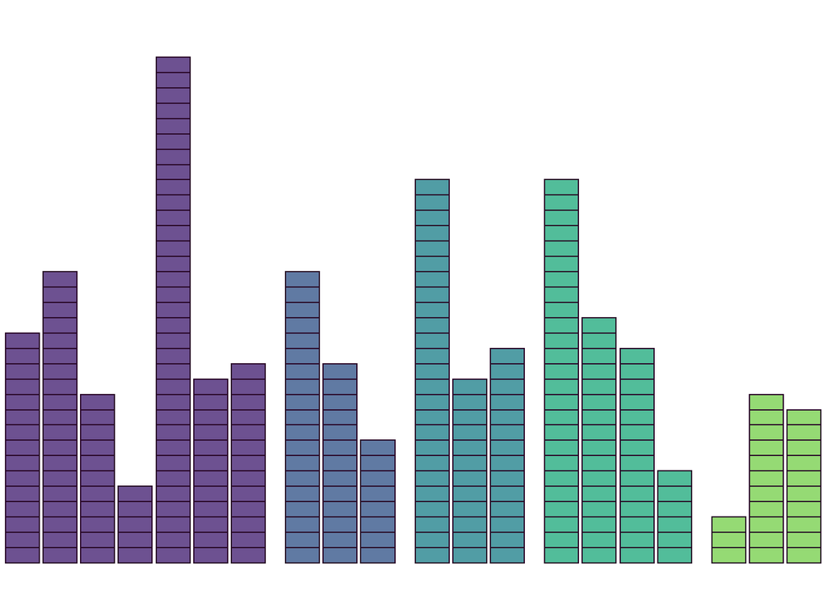

```r
df_long %>%
  group_by(chapter) %>%
  mutate(exercise_in_chapter_id = row_number()) %>%
  ungroup() %>%
  ggplot(aes(x = chapter, fill = part, group = -id)) +
  geom_bar(color = "#2a0829", alpha = 0.8, aes(fill = part)) +
  # scale_y_continuous(expand = c(.05, 0)) +
  # scale_x_discrete(expand = c(.2,0)) +

  scale_fill_viridis_d(begin = .1, end = .8)+
  facet_grid(. ~ part, scales = "free",
             space = "free", switch = "x")+
  theme_void()+
  theme(legend.position = "none",
        plot.background = element_rect(fill = "transparent", color = "transparent"),
        panel.background = element_rect(fill = "transparent", color = "transparent"),
        strip.background = element_rect(fill = "transparent", color = "transparent"),
        strip.text = element_blank()) +

  coord_cartesian(ylim = c(0, 35)) -> bar_chart

bar_chart
```

```r
ggsave(plot = bar_chart, filename = "plots/bars_henning_2.png", units = "cm", width = 16, height = 8, dpi = 600, type = "cairo-png", bg = "transparent")
```

[figure not shown]

```r
ggplot(df_long) +
    # geom_point(aes(x = part, y = chapter, color = part, size = n))+
  geom_encircle(aes(x = part, y = chapter, color = part, fill = part), expand =.003,s_shape = .5,  show.legend = FALSE, alpha = .3) +


  scale_color_viridis_d(0, end = .9) +
  scale_fill_viridis_d(begin = .2, end = .8) +
  scale_size_continuous(range = c(1, 4))+
  scale_y_discrete(expand = c(.15, 0)) +
  theme_void() +
  theme(legend.position = "none",
        plot.background = element_rect(fill = "transparent", color = "transparent"),
        panel.background = element_rect(fill = "transparent", color = "transparent"),
        strip.background = element_rect(fill = "transparent", color = "transparent"),) -> plains

plains
```

```r
ggsave(plot = plains, filename = "plots/plains_chapters_blank.png", width = 16, height = 8, units = "cm", dpi = 600, type = "cairo-png", bg = "transparent")
```

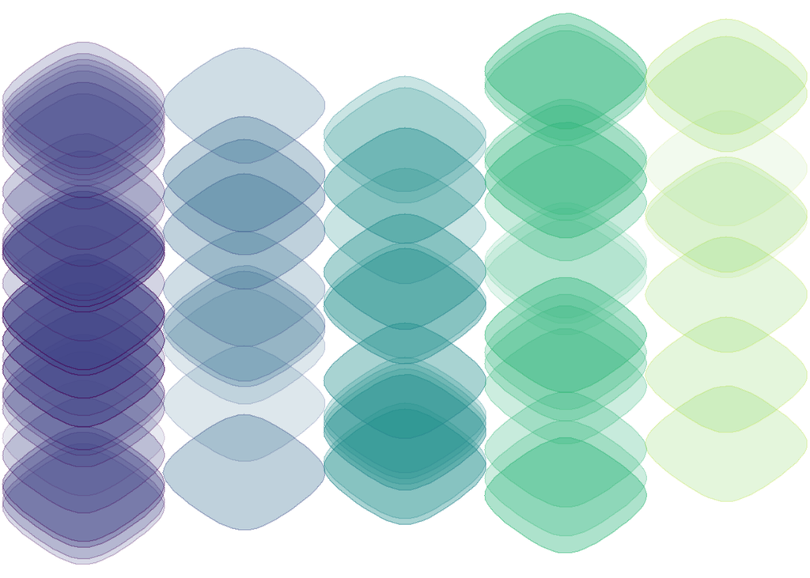

```r
ggplot(df_long) +

geom_encircle(aes(x = part, y = subchapter, color = part, fill = part, alpha = n), expand =0,s_shape = .4,  show.legend = FALSE) +



  scale_color_viridis_d(0, end = .9) +
  scale_fill_viridis_d(begin = .2, end = .8) +
  scale_size_continuous(range = c(.5, .6))+
  scale_y_discrete(expand = c(.15, 1)) +
    scale_x_discrete(expand = c(.13, 0)) +
  scale_alpha_continuous(range = c(0.1, .5))+

  theme_void() +
  theme(legend.position = "none",
        plot.background = element_rect(fill = "transparent", color = "transparent"),
        panel.background = element_rect(fill = "transparent", color = "transparent"),
        strip.background = element_rect(fill = "transparent", color = "transparent")) -> plains

plains
```

```r
ggsave(plot = plains, filename = "plots/plains_subchapters.png", width = 16, height = 8, units = "cm", dpi = 600, type = "cairo-png", bg = "transparent")
```

**3. Tree map**

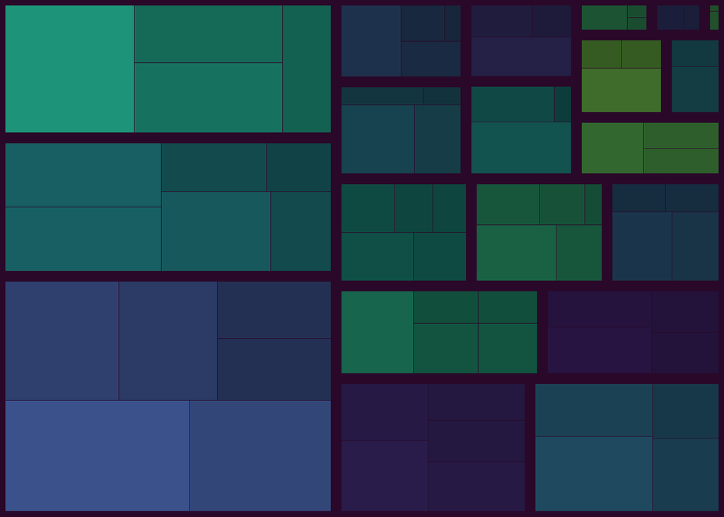

```r
ggplot(amounts, aes(area = n, fill = chapter, subgroup = chapter)) +
  geom_treemap(fill = "black") +
  geom_treemap(aes(alpha = n) , color = "#2a0829") +
  geom_treemap_subgroup_border(colour="#2a0829", size = 10) +
  scale_fill_viridis_d(begin = .1, end = .8) +
  scale_color_viridis_c()+
  scale_alpha_continuous(range = c(0.4, 1))+
  theme_void() +
  theme(legend.position = "none",
        plot.background = element_rect(fill = "#2a0829", color = "#2a0829")) -> tree_map
tree_map
```

```r
  ggsave(plot = tree_map, filename = "plots/treemap.png", width = 16, height = 8, units = "cm", dpi = 600, type = "cairo-png", bg = "transparent")
```

**4. Classic Network** First we create two network objects:

```r
net3 <- df_long %>%
  select(chapter, subchapter, part, n) %>%
  graph_from_data_frame(directed = T)

net4 <- df_long %>%
  group_by(chapter, subchapter) %>%

  count() %>%
  graph_from_data_frame(directed = FALSE)
```

```
## Using `n` as weighting variable
## i Quiet this message with `wt = n` or count rows with `wt = 1`
```

```r
is_weighted(net4)
```

```
## [1] FALSE
```

```r
#TODO on the Network plots: make the normal network plot with net4 fancier and look below comment for the new ID


#make a new network: Goal is to have excercises to chapters as as vertices/notes with part as a variable, and then as edges the link between the exercises and the chapters with subchapter as edge variable.

edges <-
  df_long %>%
  mutate(exercise_name = factor(paste0(id,"_exercise"))) %>%
  select(chapter, exercise_name, subchapter, part) %>%
  relocate(exercise_name, .after = chapter)

nodes <-
  df_long %>%
  mutate(exercise_name = factor(paste0(id,"_exercise"))) %>%
  pivot_longer(cols = c(chapter, exercise_name)) %>%
  group_by(value) %>%
  summarise(subchapter = first(subchapter),
            part = first(part))
graph_from_data_frame(d =edges, vertices = nodes) -> net_ex
```

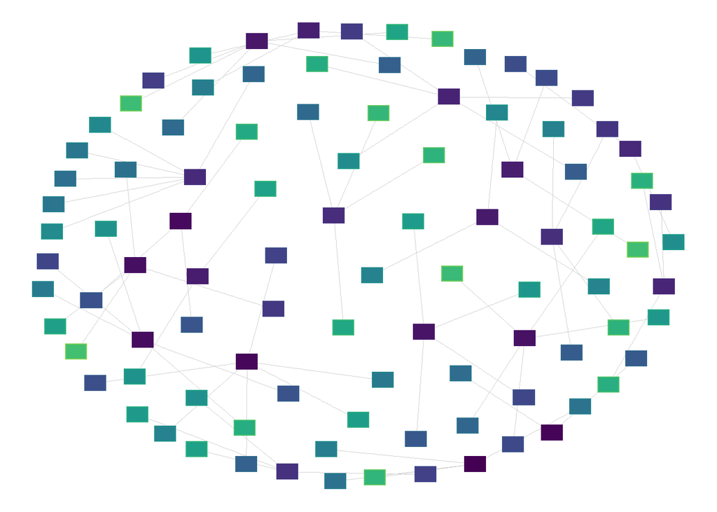

```r
# igraph_layouts <- c('star', 'circle', 'gem', 'dh', 'graphopt', 'grid', 'mds',
#                     'randomly', 'fr', 'kk', 'drl', 'lgl')
ggraph(net4, 'kk') +
  geom_edge_link(width = .1, color = "lightgrey", check_overlap = TRUE) +
  geom_node_tile(aes(color = name, fill = name), width = .5, height = .5, alpha =  1)+
  scale_color_viridis_d(end = .8)+
  scale_fill_viridis_d(end = .7)+
  scale_edge_color_viridis()+
  theme_void()+
  theme(legend.position = "none",
        plot.background = element_rect(fill = "transparent", color = "transparent")) -> classic_net



classic_net
```

```r
ggsave(plot = classic_net, filename = "plots/tile_net.png", width = 8, height = 4, units = "cm", dpi = 600, type = "cairo-png", bg = "transparent")
```

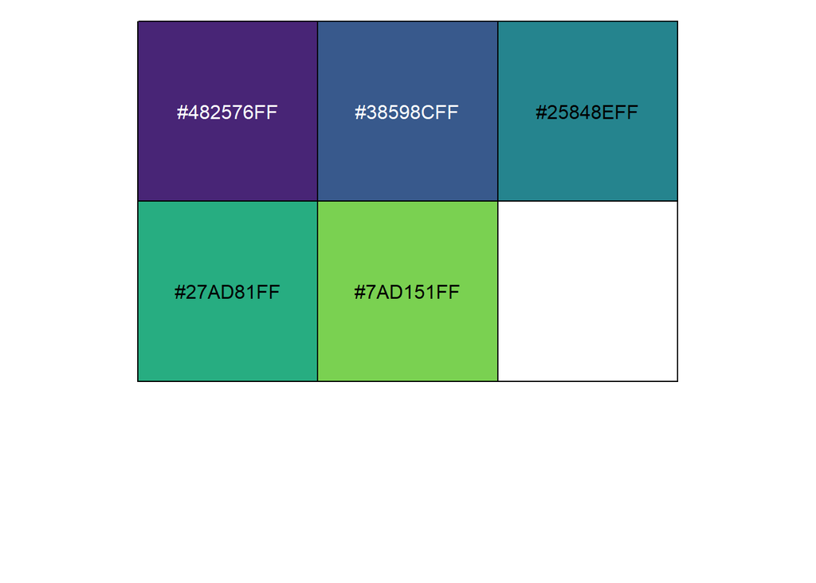

```r
# igraph_layouts <- c('star', 'circle', 'gem', 'dh', 'graphopt', 'grid', 'mds',
#                     'randomly', 'fr', 'kk', 'drl', 'lgl')


show_col(viridis_pal(end = .8, begin = .1)(5))
```

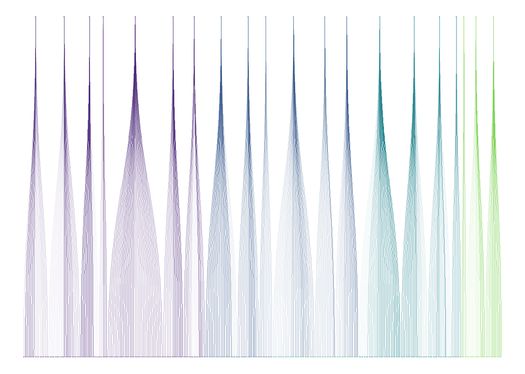

```r
ggraph(net_ex, "dendrogram") +
  geom_edge_diagonal(width =.1, aes(color = part, alpha = subchapter)) +
  geom_node_point(aes(color = part), size = .05, alpha = .8) +
  scale_edge_color_manual(values = c("#482576", "#38598c", "#25848e", "#274d81", "#7ad151"))+
  scale_color_viridis_d(end = .8, begin = .1) +
  scale_alpha_continuous(range = c(.5,1))+
  theme_void()+
  theme(legend.position = "none",
        plot.background = element_rect(fill = "transparent", color = "transparent")) -> radial_net

radial_net
```

```r
  ggsave(plot = radial_net, filename = "plots/dendro_net_ex.png", width = 8, height = 4, units = "cm", dpi = 600, type = "cairo-png", bg = "transparent")
```

**6. Extensive Exercise network**

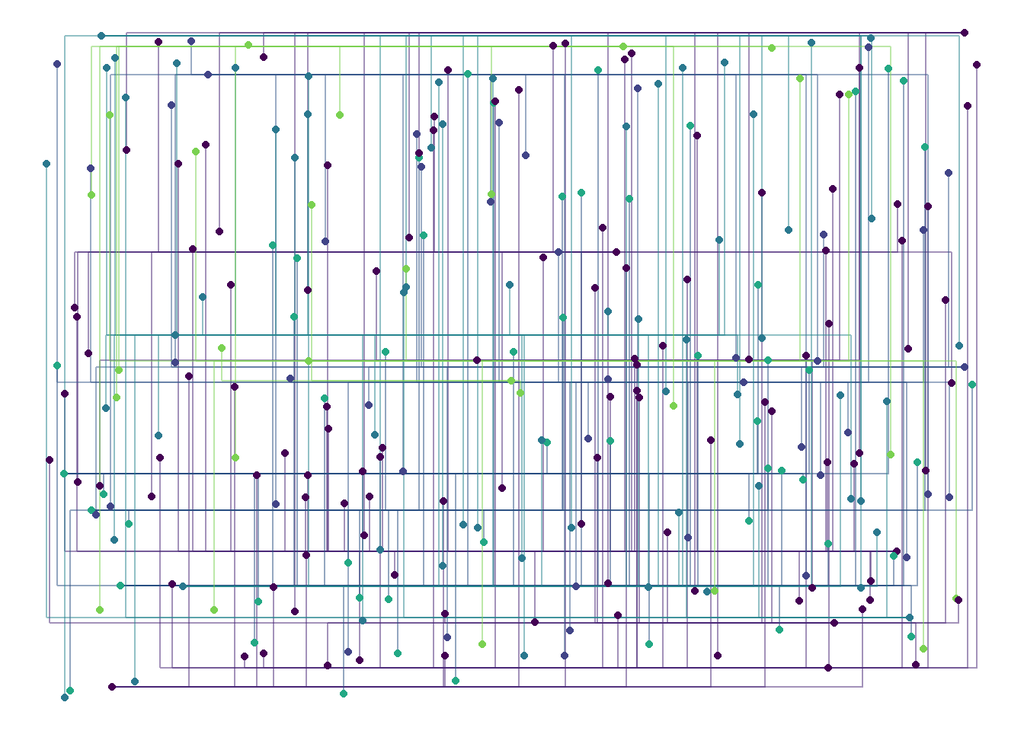

```r
# igraph_layouts <- c('star', 'circle', 'gem', 'dh', 'graphopt', 'grid', 'mds',
#                     'randomly', 'fr', 'kk', 'drl', 'lgl')
ggraph(net_ex, layout = "gem", maxiter = 1000) +
  geom_edge_elbow(aes(color = part), alpha = .5) +
  geom_node_point(aes(color = part)) +
  scale_edge_color_manual(values = c("#482576", "#38598c", "#25848e", "#274d81", "#7ad151"))+
  scale_color_viridis_d(end = .8) +
  scale_alpha_continuous(range = c(.5,1))+
  theme_void()+
  theme(legend.position = "none",
        plot.background = element_rect(fill = "transparent", color = "transparent")) -> mesh_net
mesh_net
```

```r
ggsave(plot = mesh_net, filename = "plots/mesh_net_ex.png", width = 16, height = 8, units = "cm", dpi = 600, type = "cairo-png", bg = "transparent")
```